# RRBS - BiSeq rTg4510 Part 2 - Beta Regression - Pathology

Isabel Castanho (I.S.Castanho@exeter.ac.uk)

29 March 2021

To detect the CpG sites where the DNA methylation differs due to accumulation of pathology, we model the methylation within a beta regression: Methylation = ~Pathology

```r
numCores <- detectCores()
numCores
```

```
## [1] 16
```

### 3. Model and test group effect

```r
betaResultsPathology <- betaRegression(formula = ~ECX,
                                       link = "probit",
                                       object = predictedMeth[1:10,],
                                       type = "BR",
                                       mc.cores = numCores)
# betaResults is a data.frame containing model and test information for each CpG site
# By setting type = "BR" the maximum likelihood with bias reduction is called

betaResults <- betaResultsPathology

save(betaResults, file = "/gpfs/ts0/projects/Research_Project-191406/isabel/RRBS_new/biseqBetaResultsPathology_rTg4510.RData")
```

Head results for Pathology

```r
head(betaResults)
```

```
##    chr     pos     p.val meth.group1 meth.group2     meth.diff     estimate
## 1 chr5 3020638 0.3680662  0.94053170  0.93965725  0.0008744438 -0.007349843
## 2 chr5 3020656 0.4578403  0.94058556  0.93987157  0.0007139968 -0.006011778
## 3 chr5 3021139 0.5103582  0.84060911  0.84254941 -0.0019403043  0.008026604
## 4 chr5 3021183 0.6528425  0.82839225  0.82983432 -0.0014420753  0.005679763
## 5 chr5 3021447 0.4964680  0.95188172  0.95149339  0.0003883297 -0.003869926
## 6 chr5 3341194 0.6250605  0.01582713  0.01597585 -0.0001487273  0.003735368
##     std.error pseudo.R.sqrt cluster.id
## 1 0.008165571   0.027589326     chr5_1
## 2 0.008097676   0.018517691     chr5_1
## 3 0.012193296   0.015135505     chr5_1
## 4 0.012626835   0.005109631     chr5_1
## 5 0.005690585   0.007661957     chr5_1
## 6 0.007643622   0.010348634    chr5_10
```

Summary results

```r
summary(betaResults)
```

```
##    chr          pos              p.val         meth.group1
##  chr5:10   Min.   :3020638   Min.   :0.3681   Min.   :0.01448
##            1st Qu.:3021150   1st Qu.:0.4999   1st Qu.:0.01478
##            Median :3181320   Median :0.6334   Median :0.42211
##            Mean   :3181110   Mean   :0.5889   Mean   :0.45767
##            3rd Qu.:3341208   3rd Qu.:0.6481   3rd Qu.:0.91555
##            Max.   :3341214   Max.   :0.8443   Max.   :0.95188
##   meth.group2        meth.diff             estimate           std.error
##  Min.   :0.01461   Min.   :-0.0019403   Min.   :-0.007350   Min.   :0.005691
##  1st Qu.:0.01489   1st Qu.:-0.0001444   1st Qu.:-0.002537   1st Qu.:0.007528
##  Median :0.42291   Median :-0.0001281   Median : 0.003456   Median :0.007594
##  Mean   :0.45787   Mean   :-0.0001997   Mean   : 0.001209   Mean   :0.008446
##  3rd Qu.:0.91538   3rd Qu.: 0.0002774   3rd Qu.: 0.003679   3rd Qu.:0.008149
##  Max.   :0.95149   Max.   : 0.0008744   Max.   : 0.008027   Max.   :0.012627
##  pseudo.R.sqrt       cluster.id
##  Min.   :0.002966   Length:10
##  1st Qu.:0.007994   Class :character
##  Median :0.009361   Mode  :character
##  Mean   :0.011504
##  3rd Qu.:0.013939
##  Max.   :0.027589
```

### 4.1. Test CpG clusters for differential methylation

The aim is to detect CpG clusters containing at least one differentially methylated location. To do so the P values p from the Wald tests are transformed to Z scores: z= Φ−1(1−p), which are normally distributed under Null hypothesis (no group effect). As cluster test statistic a standardized Z score average is used. To estimate the standard deviation of the Z scores we have to estimate the correlation and hence the variogram of methylation between two CpG sites within a cluster. The estimation of the standard deviation requires that the distribution of the Z scores follows a standard normal distribution. However, if methylation in both groups differs for many CpG sites the density distribution of P values shows a peak near 0.  
To ensure that the P values are roughly uniformly distributed to get a variance of the Z scores that is Gaussian with variance 1 we recommend to estimate the variogram (and hence the correlation of Z scores) under the null hypothesis. To do so we model the beta regression again for resampled data:

```r
# # Both resampled groups should have the same number of
# # cases and control samples:
# # Take bottom 16 rows of the ColData predictedMeth
# predictedMethNull <- predictedMeth[,46:61]
# # Age and Genotype selected are random to not group based on genotype or age - we selected 16 for 2 genotype, 4 time points and repeated twice to increase randomness
# colData(predictedMethNull)$group.null <- rep(c(1,2), each = 8)
# print(colData(predictedMethNull))
# # To shorten the run time, please set mc.cores, if possible!
# betaResultsNull <- betaRegression(formula = ~group.null,
#                                         link = "probit",
#                                         object = predictedMethNull,
#                                         type="BR",
#                                         mc.cores = 16)
#
# vario <- makeVariogram(betaResultsNull)
#
# save(betaResultsNull, vario, predictedMethNull,
#       file = "/gpfs/ts0/projects/Research_Project-191406/isabel/RRBS_new/biseqBetaResultsNull_rTg4510.RData")
```

```r
# Load the previous chunk betaResultsNull rdat object. Also print the samples used to generate the betaResultsNull
load("/gpfs/ts0/projects/Research_Project-191406/isabel/RRBS_new/biseqBetaResultsNull_rTg4510.RData")
print(colData(predictedMethNull))
```

```
## DataFrame with 16 rows and 8 columns
##      Mouse_ID Genotype Age_months     Group_ID Histology_no        HIP
##     <integer> <factor>   <factor>  <character>  <character>  <numeric>
## S17         9       WT          2 Tg4510_WT_2m       16/069 0.00512648
## S18        19       TG          2 Tg4510_TG_2m       16/079   0.169229
## S19        29       WT          4 Tg4510_WT_4m       16/089 0.00444578
## S20        39       TG          4 Tg4510_TG_4m       16/099    3.35796
## S21        49       WT          6 Tg4510_WT_6m       16/109  0.0384653
## ...       ...      ...        ...          ...          ...        ...
## T20        60       TG          6 Tg4510_TG_6m       16/120    7.53909
## T21        70       WT          8 Tg4510_WT_8m       16/130   0.194898
## T22        80       TG          8 Tg4510_TG_8m       16/140    24.1731
## T23        10       WT          2 Tg4510_WT_2m       16/070  0.0102485
## T24        20       TG          2 Tg4510_TG_2m       16/080   0.140746
##             ECX group.null
##       <numeric>  <numeric>
## S17 0.000650575          1
## S18     3.90475          1
## S19 0.000984173          1
## S20     5.41229          1
## S21  0.00169621          1
## ...         ...        ...
## T20      11.437          2
## T21  0.00369588          2
## T22      9.9359          2
## T23           0          2
## T24     3.06044          2
```

We estimate the variogram for the Z scores obtained for the resampled data.  
Based on the variogram plot we evaluate the sill (usually near 1) of the variogram and smooth the curve:

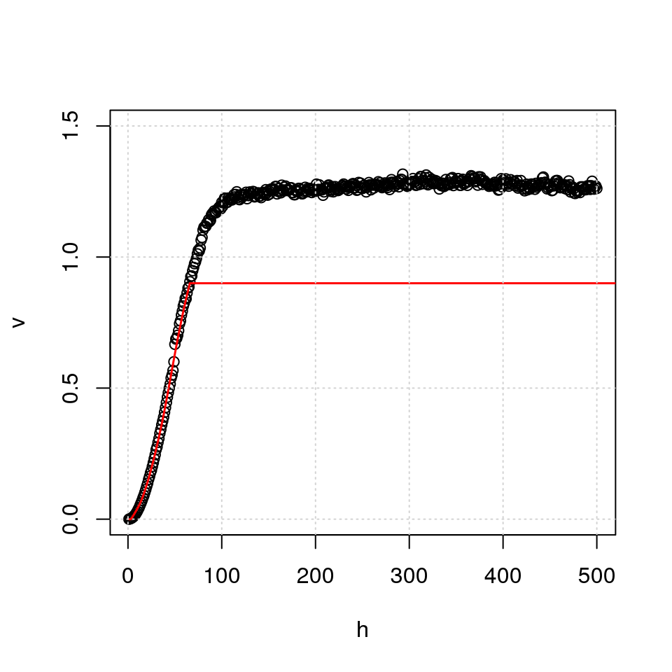

Figure 5: Estimated variogram together with the smoothed curve

```r
plot(vario$variogram$v, ylim = c(0, 1.5))
vario.sm <- smoothVariogram(vario, sill = 0.9) # The vario.sm object is a list of two: "variogram" "pValsList"
lines(vario.sm$variogram[,c("h", "v.sm")],col = "red", lwd = 1.5)
grid()
```

```r
# # Save all ojects from betaResultsNull
# resave(betaResultsNull, vario, vario.sm, predictedMethNull,
#      file = "/gpfs/ts0/projects/Research_Project-191406/isabel/RRBS_new/biseqBetaResultsNull_rTg4510.RData")
```

```r
head(vario.sm$pValsList[[1]])
```

```
##           chr     pos     p.val meth.group1 meth.group2   meth.diff    estimate
## 8.95436  chr1 3147799 0.5452383   0.9606191   0.9514922 0.009126935 -0.09841902
## 9.95436  chr1 3147811 0.4550362   0.9609271   0.9495239 0.011403234 -0.12129300
## 10.95436 chr1 3147812 0.4468710   0.9609887   0.9493937 0.011595046 -0.12327377
## 11.95436 chr1 3147838 0.3211288   0.9595434   0.9439699 0.015573460 -0.15641067
## 12.95436 chr1 3147839 0.3147145   0.9596333   0.9438367 0.015796614 -0.15862469
## 13.95436 chr1 3147841 0.3117537   0.9593632   0.9432833 0.016079905 -0.16039615
##          std.error pseudo.R.sqrt cluster.id    z.score pos.new
## 8.95436  0.1627001    0.02691297     chr1_1 -0.1136397       1
## 9.95436  0.1623637    0.04283508     chr1_1  0.1129471      13
## 10.95436 0.1620655    0.04455054     chr1_1  0.1335707      14
## 11.95436 0.1576496    0.08044663     chr1_1  0.4645448      40
## 12.95436 0.1577761    0.08238313     chr1_1  0.4825306      41
## 13.95436 0.1585649    0.08354874     chr1_1  0.4908855      43
```

vario.sm contains the smoothed variogram under the Null hypothesis together with the P values (and Z scores) from the Wald test, that the group has no effect on methylation. The correlation of the Z scores between two locations in a cluster can now be estimated:

```r
locCor <- estLocCor(vario.sm)
```

We test each CpG cluster for the presence of at least one differentially methylated location at q what can be interpreted as the size-weighted FDR on clusters:

```r
clusters.rej <- testClusters(locCor, FDR.cluster = 0.10)
```

```
## 127 CpG clusters rejected.
```

```r
clusters.rej$clusters.reject
```

```
## GRanges object with 127 ranges and 2 metadata columns:
##         seqnames              ranges strand |           X              p.value
##            <Rle>           <IRanges>  <Rle> | <character>            <numeric>
##     [1]     chr1 118097468-118097521      * |   chr1_2656 5.58442181386454e-14
##     [2]     chr1 130006916-130006952      * |   chr1_2939 1.72129053155334e-06
##     [3]     chr1 143971600-143971641      * |   chr1_3556  6.6265648053454e-05
##     [4]     chr1 148096033-148096775      * |   chr1_3578 4.69272275368526e-05
##     [5]     chr1 171036581-171037298      * |   chr1_4281 8.23935403237996e-08
##     ...      ...                 ...    ... .         ...                  ...
##   [123]     chrX   95350321-95350355      * |   chrX_1290 1.10817209852954e-08
##   [124]     chrX   97403240-97403338      * |   chrX_1317  2.9752628092683e-05
##   [125]     chrX   15888976-15889169      * |    chrX_308 3.48873625138912e-05
##   [126]     chrX   48366072-48366142      * |    chrX_637  5.0180458243787e-05
##   [127]     chrX   65002557-65002713      * |    chrX_885 9.37053820093681e-08
##   -------
##   seqinfo: 22 sequences from an unspecified genome; no seqlengths
```

### 4.2. Trim significant CpG clusters

```r
clusters.trimmed <- trimClusters(clusters.rej, FDR.loc = 0.10)
head(clusters.trimmed)
```

```
##                     chr       pos        p.val meth.group1 meth.group2
## chr1_2656.14.98704 chr1 118097468 3.663059e-09   0.9077439   0.8759404
## chr1_2656.15.98704 chr1 118097497 2.200964e-12   0.9114533   0.8737352
## chr1_2656.16.98704 chr1 118097498 1.525417e-12   0.9115081   0.8735443
## chr1_2656.1.98705  chr1 118097501 4.724575e-13   0.9106264   0.8719775
## chr1_2656.2.98705  chr1 118097502 3.260410e-13   0.9104187   0.8713872
## chr1_2656.3.98705  chr1 118097504 1.141242e-13   0.9095916   0.8697188
##                     meth.diff   estimate  std.error pseudo.R.sqrt cluster.id
## chr1_2656.14.98704 0.03180354 -0.1720598 0.02916895     0.7374733  chr1_2656
## chr1_2656.15.98704 0.03771802 -0.2055314 0.02927331     0.7982140  chr1_2656
## chr1_2656.16.98704 0.03796376 -0.2067938 0.02924054     0.8004690  chr1_2656
## chr1_2656.1.98705  0.03864892 -0.2088338 0.02887239     0.8073861  chr1_2656
## chr1_2656.2.98705  0.03903147 -0.2103647 0.02888363     0.8093908  chr1_2656
## chr1_2656.3.98705  0.03987274 -0.2131811 0.02871733     0.8150580  chr1_2656
##                     z.score pos.new         p.li
## chr1_2656.14.98704 5.783273       1 3.171192e-05
## chr1_2656.15.98704 6.923637      30 3.544017e-08
## chr1_2656.16.98704 6.975362      31 2.456244e-08
## chr1_2656.1.98705  7.138301      34 7.607566e-09
## chr1_2656.2.98705  7.189124      35 5.249949e-09
## chr1_2656.3.98705  7.331113      37 1.837641e-09
```

```r
# clusters.trimmed is a data.frame object containing all differentially methylated CpG sites. The p.li column contains the P values estimated in the cluster trimming step
```

### 5. Defnition of DMR boundaries

```r
DMRs <- findDMRs(clusters.trimmed,
                 max.dist = 500,
                 diff.dir = TRUE)
DMRs
```

```
## GRanges object with 31 ranges and 4 metadata columns:
##        seqnames              ranges strand |             median.p
##           <Rle>           <IRanges>  <Rle> |            <numeric>
##    [1]     chr1 118097468-118097521      * | 2.68563220242889e-13
##    [2]     chr1 171037270-171037298      * | 2.24102624223043e-07
##    [3]    chr10            60323489      * | 8.16057310778737e-06
##    [4]    chr10            99085056      * | 3.07432346292588e-06
##    [5]    chr11            45762973      * | 6.53381124694694e-07
##    ...      ...                 ...    ... .                  ...
##   [27]     chr9 107723539-107723555      * |  2.7099532725584e-08
##   [28]     chr9 117011310-117011354      * | 3.04908265087704e-06
##   [29]     chrX            48366072      * | 1.28891587662854e-05
##   [30]     chrX   65002557-65002580      * | 1.67549131121015e-07
##   [31]     chrX   95350325-95350355      * | 1.14229949194126e-08
##        median.meth.group1 median.meth.group2    median.meth.diff
##                 <numeric>          <numeric>           <numeric>
##    [1]  0.910522544712195  0.872760904650739  0.0384931985066387
##    [2]  0.205176199883929 0.0397962789225124   0.165536606303586
##    [3]  0.999233213600827  0.988421207113761  0.0108120064870662
##    [4]  0.173370579561638 0.0397354743726314   0.133635105189006
##    [5]  0.592205280565809  0.892517492247039   -0.30031221168123
##    ...                ...                ...                 ...
##   [27]  0.669878203887629  0.203231010149461   0.466678934589726
##   [28]  0.282359333907002   0.77732437389692  -0.494965039989919
##   [29]  0.038868862507637  0.413532587957729  -0.374663725450092
##   [30]   0.99842505002113  0.985426159849721  0.0129807284738024
##   [31]  0.999945116459931  0.995443634812993 0.00450148164693748
##   -------
##   seqinfo: 22 sequences from an unspecified genome; no seqlengths
```

```r
DMRsPathology <- as.data.frame(DMRs)
write.csv(DMRsPathology, file = "/gpfs/ts0/projects/Research_Project-191406/isabel/RRBS_new/DMRs/rTg4510/DMRsPathology.csv")

DMRsPathology <- DMRs
save(betaResultsPathology, DMRsPathology,
     file = "/gpfs/ts0/projects/Research_Project-191406/isabel/RRBS_new/biseqResultsPathology_rTg4510.RData")
```